# Digital Equity Information - Dane County Wisconsin

Deanna Schneider

2023-05-04

The following information is based on the most recent 5-year American community survey data (ending with 2021).

## Households with a Computer

Most households in Dane County have a computer, and the percent of households in Dane County with a computer exceeds the percent of households with a computer for the state of Wisconsin. But, block group data reveals a disparity in percent of households with a computer by neighborhood, with certain neighborhoods within the county have a much lower percentage of the household owning a computer.

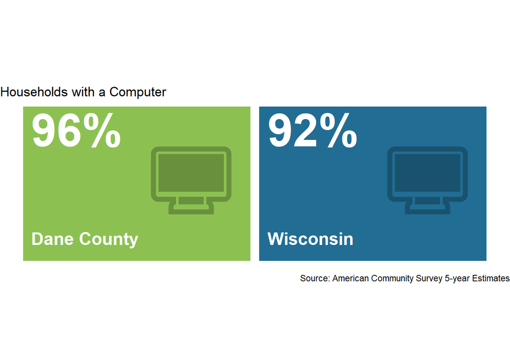

[interactive chart not shown]

## No Internet Access

When viewed at the county or state level, most households that have a computer have some form of internet access. But pockets exist within Dane County in which a much higher percent of households do not have internet access, even while having a computer.

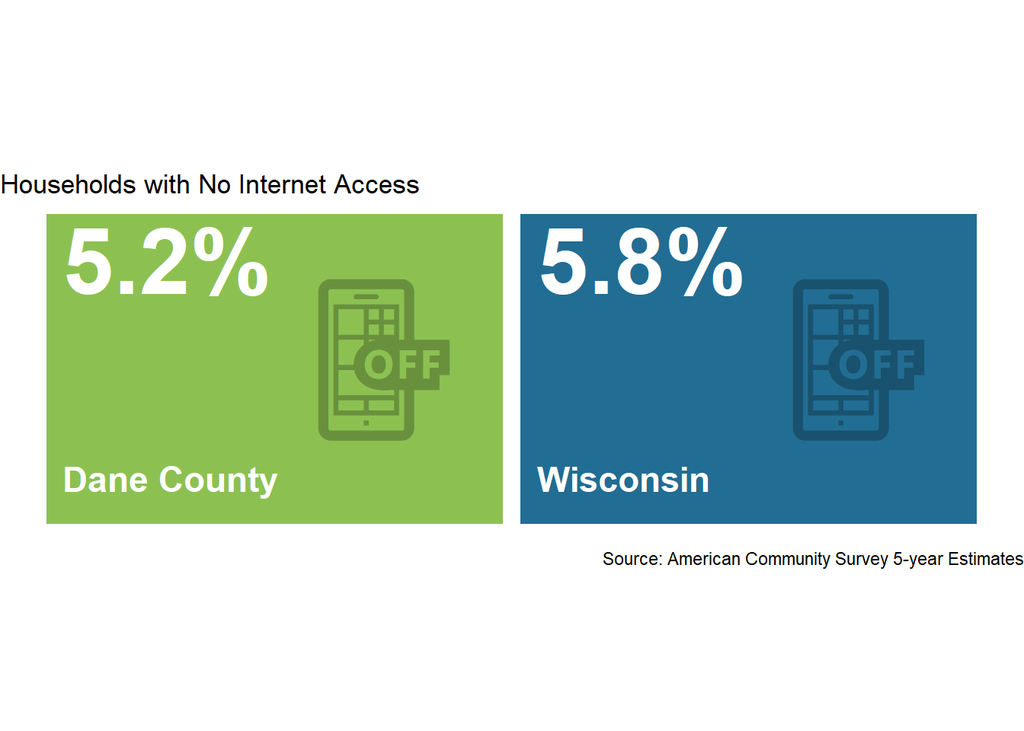

[interactive chart not shown]

## Dial-up Access Only

In both Dane County and Wisconsin, the percentage of households that have a computer, but only have dial-up access, is extremely low. A greater disparity is once again seen at the block group level, with some rural and urban block groups showing higher percentages of dial-up only access.

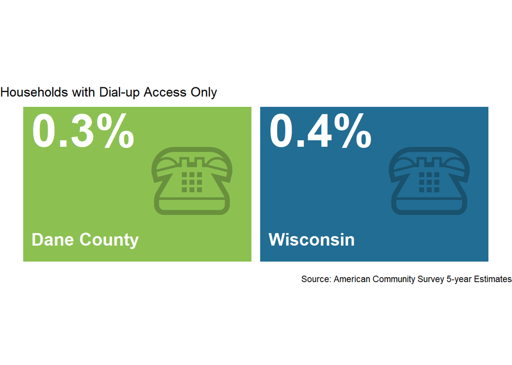

[interactive chart not shown]

## Broadband Access

Dane County exceeds Wisconsin in the percentage of households that have a computer and broadband access. But again, the distribution of that broadband access throughout the county is inconsistent.

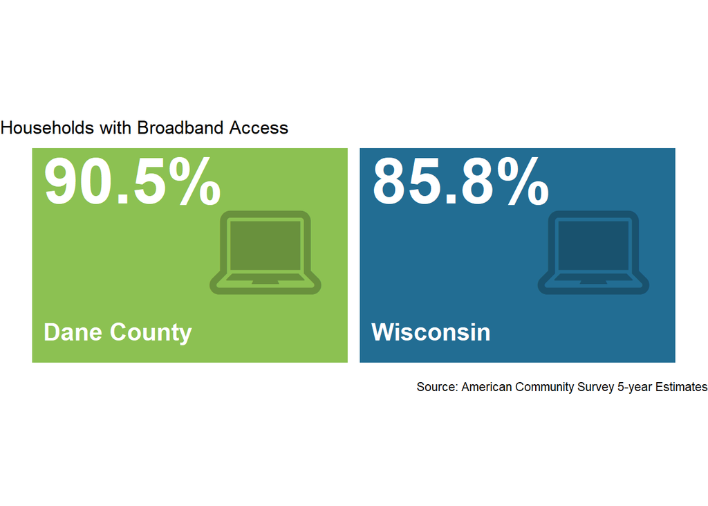

[interactive chart not shown]